# Medidas de tendencia central

[Roberto Cruz De La vega](https://rbtcdv.github.io)

Estadística 2022-2, [Facultad de economía](http://www.economia.unam.mx/)

2/3/2022

### 1. ¿Qué son las medidas de tendencia central? 🤠

> “Las medidas de tendencia central son parámetros estadísticos que informan sobre el centro de la distribución de la muestra o población estadística”

[Economipedia (2022)](https://economipedia.com/definiciones/medidas-de-tendencia-central.html)

Para este ejemplo, primero generaremos una serie de **100** números aleatorios entre **1** y **20** mediante la función `sample`. El argumento `TRUE` nos permitirá generar una muestra con remplazo:

```r
numeros <- sample(1:20, 100, TRUE)
numeros
```

```
##   [1]  3  3  2 12 12 15  5 19 13  5 12  1  4 13 17  5 10 10 15 11 14  2  2 16  8
##  [26] 16 10 19 14 14 18  1  8 14 13 20  1  3  6 14 14  4 14  7 20 10 18  4  8  3
##  [51] 13 18  1 19 10 20 14 16  4  4 13 11  2 16 18  4 17  5  3 16  6  1  5  6 13
##  [76] 20  9  2 14  2 12  1  5 12  5  3 14 19 14 15 13 10 11 17  5 15 16 12  8 16
```

### 2. Mediana 📍

> “La mediana representa el valor de la variable de posición central en un conjunto de datos ordenados”

Wikipedia (2022)🤨

Para obtener la **mediana**, podemos ordenar los `numeros` de menor a mayor, **el número que esté en medio de la muestra será la mediana**. Si utilizamos R, se puede hacer el cálculo de la **mediana** con la función `median`:

```r
mediana <- median(numeros)
mediana
```

```
## [1] 11.5
```

### 3. Media 🧮

> “La media es el valor promedio de un conjunto de datos numéricos, calculada como la suma del conjunto de valores dividida entre el número total de valores”

[Economipedia (2022)😘](https://economipedia.com/definiciones/media.html)

$$Media ={\frac {1}{n}}\sum
_{i=1}^{n}a_{i}={\frac {a_{1}+a_{2}+\cdots +a_{n}}{n}}$$

Si usamos R, podemos obtener la media de una muestra si utlilizamos la función **mean**:

```r
media <- mean(numeros)
media
```

```
## [1] 10.27
```

### 4. Moda 📊

> Definición: “La moda es el valor que aparece con mayor frecuencia en un conjunto de datos”

Wikipedia (2022)😶

Podemos saber cuál es la **frecuencia** (número de veces que aparece un elemento en una muestra) de cada número si dibujamos un **histograma** con la función `hist`, **aquel elemento con mayor frecuencia será la moda**:

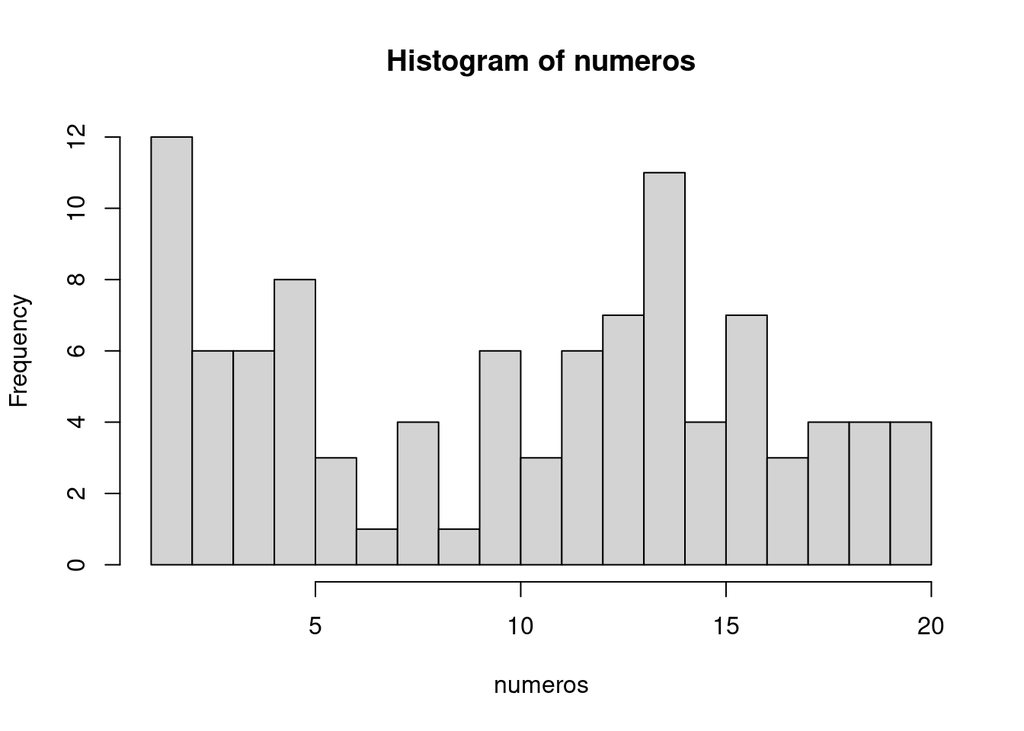

```r
# El argumento breaks nos permite dividir en histograma en las partes que queramos
hist(numeros, breaks = 20)
```

Para obtener un resultado con más precisión, podemos obtener la **moda** si generamos una **tabla de frecuencias** con la función `table` y la función `data.frame`, **aquel elemento con mayor frecuencia será la moda**:

```r
tabla.frecuencias <- data.frame(table(numeros))
tabla.frecuencias
```

```
##    numeros Freq
## 1        1    6
## 2        2    6
## 3        3    6
## 4        4    6
## 5        5    8
## 6        6    3
## 7        7    1
## 8        8    4
## 9        9    1
## 10      10    6
## 11      11    3
## 12      12    6
## 13      13    7
## 14      14   11
## 15      15    4
## 16      16    7
## 17      17    3
## 18      18    4
## 19      19    4
## 20      20    4
```

### 5. Ejercicio 👩‍💻👨‍💻✍

Aplica lo que aprendiste, obten la **mediana**, **media** y **moda** de la siguiente muestra de números:

```r
# Con la función seq, creamos una secuencia de 1 a 10 en intervalos de 0.1 en 0.1
secuencia <- seq(1, 10, 0.1)
muestra <- sample(secuencia, 100, TRUE)
muestra
```

```
##   [1]  3.2  7.6  4.0  6.1  9.8  7.9  9.1  2.8  4.5  8.2  3.9  3.6  9.2  5.1  8.6
##  [16]  6.0  8.7  2.3  1.3  1.2  2.9  6.6  5.3  9.1  9.5  1.1  9.3  4.5  1.7  5.3
##  [31]  3.9  2.6  5.3  7.3  5.2  7.8  9.0  1.4  8.5  9.0  6.1  6.6  5.9  6.9  1.1
##  [46]  3.2  1.6  8.0  2.2  6.1  7.4  6.7  3.9  4.2  7.3 10.0  4.8  7.4  7.9  7.0
##  [61]  3.1  7.2  2.3  1.7  2.3  2.3  6.9  8.5  7.6  4.0  9.6  2.4  1.0  1.7  9.6
##  [76]  9.4  2.5  3.0  7.4  8.3  2.5  3.4  8.7  4.9  1.9  7.1  3.6  9.0  3.9  7.1
##  [91]  7.4  4.5  6.4  1.2  4.7  7.3  7.2  9.0  8.8  2.5
```

##### Mediana

```r
mediana.muestra <- median(muestra)
mediana.muestra
```

```
## [1] 5.95
```

##### Media

```r
media.muestra <- mean(muestra)
media.muestra
```

```
## [1] 5.546
```

##### Moda

```r
tabla.moda <- data.frame(table(muestra))
tabla.moda
```

```
##    muestra Freq
## 1        1    1
## 2      1.1    2
## 3      1.2    2
## 4      1.3    1
## 5      1.4    1
## 6      1.6    1
## 7      1.7    3
## 8      1.9    1
## 9      2.2    1
## 10     2.3    4
## 11     2.4    1
## 12     2.5    3
## 13     2.6    1
## 14     2.8    1
```

[output cut: 47 more lines]

💻[Código disponible en RStudio Cloud](https://rstudio.cloud/project/3671022)💻